# R Notebook

#librerias utilizadas

```r
library(mongolite)
library(jsonlite)
library(sqldf)
options(gsubfn.engine="R")
library(wordcloud2)
```

#obtener datos de mongodb

```r
db <- mongo(collection = "retweets", db = "DMUBA")

retweets = mongo(db = "DMUBA", collection = "retweets")

df_retweets = retweets$find()

nrow(df_retweets)
```

```
[1] 21286
```

#Analisis para ARGENTINA #1-Alcance: todos los retweets que tengan Argentina en el atributo location #A) quien es el autor mas retweeteado? # obtener datos totales agrupados por el autor del tweet retweeteado

```r
stringsql1 = "select retweet_screen_name,count(*) as total from df_retweets where retweet_location like '%Argentina%' group by retweet_screen_name"

autorarg = sqldf(stringsql1)
```

[output not shown]

[output cut: 748 more lines]

#grafico de wordcloud #el autor con mas retweet es AnguitaExe

```r
wordcloud2(data=autorarg, size=0.2, color='random-dark')
```

[interactive chart not shown]

#2) Cual es el texto del tweet mas retweeteado? #obtener datos

```r
stringsql2 = "select retweet_text,count(*) as total from df_retweets where retweet_location like '%Argentina%' group by retweet_text order by 2 desc"

tweetarg = sqldf(stringsql2)

print(tweetarg[1:1,])
```

|  | retweet_text | total |
| --- | --- | --- |
| 1 | el coronavirus arruinó lo q podría haber sido de onda mi mejor año | 53 |

```r
NA
```

#2-Alcance: todos los retweets que tengan Argentina en el atributo location y oticias en description

#1)Quien es el autor correspondiente a un medio de noticias mas retweeteado? #Obtener datos totales agrupados por el autor/medio de noticias del tweet retweeteado

```r
stringsql3 = "select retweet_screen_name,count(*) as total from df_retweets where retweet_location like '%Argentina%' and retweet_description like '%oticias%' group by retweet_screen_name"

autornotarg = sqldf(stringsql3)
```

```r
summary(autornotarg)
```

```
 retweet_screen_name     total
 Length:30           Min.   : 1.0
 Class :character    1st Qu.: 1.0
 Mode  :character    Median : 1.0
                     Mean   : 4.7
                     3rd Qu.: 3.5
                     Max.   :29.0
```

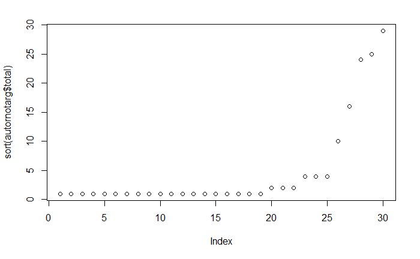

```r
plot(sort(autornotarg$total))
```

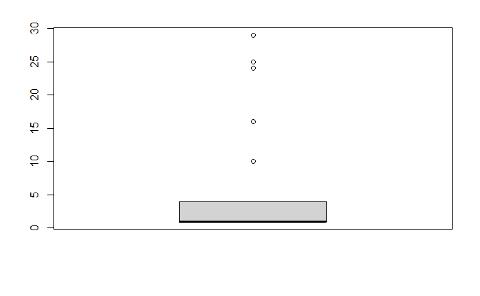

```r
boxplot(autornotarg$total)
```

##grafico de wordcloud #el autor correspondiente a un medio de noticias con mas retweet es todonoticias

```r
wordcloud2(data=autornotarg, size=0.3, color='random-dark')
```

[interactive chart not shown]

#2) Cual es el texto del tweet del medio de noticias con mas retweeteado? #obtener datos

```r
stringsql4 = "select retweet_text,count(*) as total from df_retweets where retweet_location like '%Argentina%' and retweet_description like '%oticias%' group by retweet_text order by 2 desc"

tweetnotarg = sqldf(stringsql4)

print(tweetnotarg[1:1,])
```

|  | retweet_text | total |
| --- | --- | --- |
| 1 | Coronavirus en la Argentina \| Rebajarán 12% los honorarios de los médicos del Hospital Italiano https://t.co/AVWx3zwik7 | 9 |

```r
NA
```